# Kernel Density Estimation

In this project, we will use a psychological experiment dataset to study whether or not the two brain regions are likely to be independent of each other and considering different types of political view For this question; The data set \textsf{n90pol.csv} contains information on 90 university students who participated in a psychological experiment designed to look for relationships between the size of different regions of the brain and political views. The variables amygdala and acc indicate the volume of two particular brain regions known to be involved in emotions and decision-making, the amygdala and the anterior cingulate cortex; more exactly, these are residuals from the predicted volume, after adjusting for height, sex, and similar body-type variables. The variable \textsf{orientation} gives the students' locations on a five-point scale from 1 (very conservative) to 5 (very liberal). Note that in the dataset, we only have observations for orientation from 2 to 5.

We begin by loading in all of our necessary packages as well as the dataset which we will display a preview of below:

```python
from __future__ import print_function
import numpy as np
import math
import sklearn.preprocessing
import pandas as pd
import matplotlib.pyplot as plt
import scipy.stats
import scipy.io
import seaborn as sns
import KDEpy
from matplotlib import cm
from ipywidgets import interact, interactive, fixed, interact_manual
import ipywidgets as widgets
from mpl_toolkits.mplot3d import axes3d
%matplotlib inline
psych_df = pd.read_csv('n90pol.csv')
amygdala = np.array(psych_df['amygdala'])
acc = psych_df['acc']
orientation = np.array(psych_df['orientation'])
dual_array = np.array(psych_df[['amygdala','acc']])
display(psych_df)
```

|  | amygdala | acc | orientation |
| --- | --- | --- | --- |
| 0 | 0.0051 | -0.0286 | 2 |
| 1 | -0.0674 | 0.0007 | 3 |
| 2 | -0.0257 | -0.0110 | 3 |
| 3 | 0.0504 | -0.0167 | 2 |
| 4 | 0.0125 | -0.0005 | 5 |
| ... | ... | ... | ... |
| 85 | 0.0174 | -0.0242 | 2 |
| 86 | 0.0251 | -0.0087 | 3 |
| 87 | 0.0676 | 0.0120 | 2 |
| 88 | -0.0097 | -0.0239 | 3 |
| 89 | 0.0374 | 0.0502 | 3 |

90 rows × 3 columns

### Interactive Amygdala Histogram:

Next, we plot each of the non-label features in the dataset via a 1D histogram to get a better understanding of the distribution of each feature’s data. The histogram methodology has some flexibility in how to choose the number of bins, I have supplied interactive charts below that use sliders to update the plots to your chosen number of bins to display. By default, each plot is set at the number of bins I found most intuitive for observing the plots. These plots are listed below along with some other static charts of other intersecting values of bandwidth:

```python
def amygdala_hist(Bins):
    plt.hist(amygdala,density=True,label='Histogram',edgecolor='#1f77b4',bins=Bins,color='w')
    plt.legend(loc='best')
    plt.xlabel('%s Bins'% Bins)
    plt.ylabel('Frequency')
    plt.title('Histogram of Amygdala Data')
widgets.interact(amygdala_hist,Bins=(2,20))
plt.show()
```

The Plot above displays a visualization of the Amygdala dataset feature plotted along 11 histogram bins. After playing with various bin values, I arrived at 11 as the final choice as this in my opinion represents a good parameterization structure of the distribution. As we can see the chart shows a distinct mean, but not quite symmetric structure given the large left tail.

### Static Amygdala Histograms of Varying Bandwidth:

Next, I will select some interesting values of bins and plot them side by side for direct comparison.

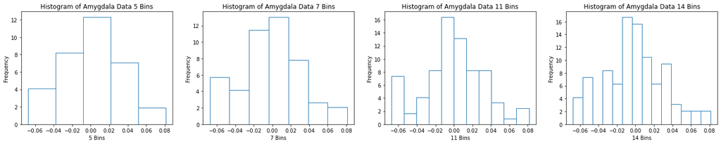

```python
fig,axs = plt.subplots(nrows=1,ncols=4,figsize=(24,4))
axs[0].hist(amygdala,density=True,label='Histogram',edgecolor='#1f77b4',bins=5,color='w')
axs[0].set_title('Histogram of Amygdala Data 5 Bins')
axs[0].set_xlabel('5 Bins')
axs[0].set_ylabel('Frequency')
axs[1].hist(amygdala,density=True,label='Histogram',edgecolor='#1f77b4',bins=7,color='w')
axs[1].set_title('Histogram of Amygdala Data 7 Bins')
axs[1].set_xlabel('7 Bins')
axs[1].set_ylabel('Frequency')
axs[2].hist(amygdala,density=True,label='Histogram',edgecolor='#1f77b4',bins=11,color='w')
axs[2].set_title('Histogram of Amygdala Data 11 Bins')
axs[2].set_xlabel('11 Bins')
axs[2].set_ylabel('Frequency')
axs[3].hist(amygdala,density=True,label='Histogram',edgecolor='#1f77b4',bins=14,color='w')
axs[3].set_title('Histogram of Amygdala Data 14 Bins')
axs[3].set_xlabel('14 Bins')
axs[3].set_ylabel('Frequency')
plt.show()
```

The above static charts of Amygdala histograms with varying bin numbers allow us to understand the data a bit more. As we can see under bin 5, the distribution seems very approachable and nearly normal aside from a slight skewness. However, it is important to acknowledge that although this is a nice smoother representation of the data, the low number of bins causes us to lose valuable information on the distribution of data by grouping our data in broader buckets. Moving onto the 7-bin chart we see a slightly jumpier structure of the 5-bin example. This makes a good representation as it captures more of the data's structure while keeping all bins populated (a main challenge of increasing bin numbers). The distribution still displays the skewness as displayed in the 5-bin example. Next, we move onto the 11-bin example. Under the 11-bin approach we can see our mean is much more defined with respect to the other data. Additionally, we have been able to fill all buckets thus making the discrete representation of the data's distribution somewhat less disjoint. However, it is notable that our first bin in this model demonstrates very high frequency for a grouping that should (in theory under a normal gaussian) fall into the left tail and thus be far less frequent. Of further interest is how our prior graphs had this same skewness, but the causes of which were largely hidden until we expanded enough bins to see that far left values isolated in the extreme low of the data were causing the skewness and they were in fact not more equally distributed among the left side of the distribution. For this reason, I chose to select 11 bins as our optimal representation. Additionally, as we see for our final chart in the 14-bin case that at this level of bins we fail to attain non-empty bins. Next, we move onto the next non-label feature in the dataset the Anterior Cingulate Cortex Volume known referred to further on as "Acc".

### Anterior Cingulate Cortex Histogram:

We now take the same approach and methodology given above and apply this to our last non-label feature vector the Anterior Cingulate Cortex also known as Acc. These results are demonstrated below first via interactive chart with flexible bins parameter and farther below static plots of interesting values of the bins parameter:

```python
def acc_hist(Bins):
    plt.hist(acc,density=True,label='Histogram',edgecolor='#1f77b4',bins=Bins,color='w')
    plt.legend(loc='best')
    plt.xlabel('%s Bins'% Bins)
    plt.ylabel('Frequency')
    plt.title('Histogram of Acc Data')
widgets.interact(acc_hist,Bins=(2,20))
plt.show()
```

### Static Acc Histograms of Varying Bandwidth:

Next, I will select some interesting values of bins and plot them side by side for direct comparison.

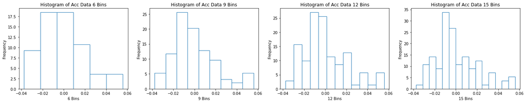

```python
fig,axs = plt.subplots(nrows=1,ncols=4,figsize=(24,4))
axs[0].hist(acc,density=True,label='Histogram',edgecolor='#1f77b4',bins=6,color='w')
axs[0].set_title('Histogram of Acc Data 6 Bins')
axs[0].set_xlabel('6 Bins')
axs[0].set_ylabel('Frequency')
axs[1].hist(acc,density=True,label='Histogram',edgecolor='#1f77b4',bins=9,color='w')
axs[1].set_title('Histogram of Acc Data 9 Bins')
axs[1].set_xlabel('9 Bins')
axs[1].set_ylabel('Frequency')
axs[2].hist(acc,density=True,label='Histogram',edgecolor='#1f77b4',bins=12,color='w')
axs[2].set_title('Histogram of Acc Data 12 Bins')
axs[2].set_xlabel('12 Bins')
axs[2].set_ylabel('Frequency')
axs[3].hist(acc,density=True,label='Histogram',edgecolor='#1f77b4',bins=15,color='w')
axs[3].set_title('Histogram of Acc Data 15 Bins')
axs[3].set_xlabel('15 Bins')
axs[3].set_ylabel('Frequency')
plt.show()
```

The above plots consider various parameterizations of the histogram bins value. The comparison of each plot follows similar observations to those explained in the amygdala histogram. We see that with our lowest bin values such as 6 in the case of Acc our data is too smooth and hides too much structure to be of value for analysis. However, as we move to higher values of bins such as 12 and more specifically 15 we see that the visualization becomes too noisy and in the case of 15 bins specifically, disjoined with empty bins. For these reasons just as before I find it most suitable to use the 9 bins middle of the road estimate for best parameterization of the histogram bins for Acc. In this case our data again displays some skewness just as in the amygdala. This could demonstrate that there is a deeper relationship behind these similar distribution shapes, but such an assertion would require more analysis with rigor beyond a simple histogram plot. We will explore such alternate methods in the analysis below beginning with Kernel Density Estimation.

### Amygdala Gaussian Kernel Density Estimator:

With each our 1-D histograms plotted above; we can now move on an alternate more flexible approach for observing our data's distributional properties using the KDE method of density estimation. These output plots are displayed below beginning with an interactive KDE chart with user defined bandwidth parameterization initialized at the recommended Silverman bandwidth, and followed by static plots of various interesting values of bandwidth each visualized side-by-side for direct comparison:

```python
def amygdala_kde_single(bandwidth):
    sns.kdeplot(sklearn.preprocessing.scale(amygdala),bw=bandwidth,shade=True)
    plt.title('Amygdala Gaussian KDE with Bandwidth = %s'%bandwidth)
    plt.ylabel('Density')
    plt.xlabel('Scaled Anygdala Values')
widgets.interact(amygdala_kde_single, bandwidth=widgets.FloatSlider(min=.01,max=1.0,step=0.01, value=round(scipy.stats.gaussian_kde(sklearn.preprocessing.scale(amygdala),bw_method='silverman').factor,2)))
plt.show()
```

The above chart displays the Gaussian Kernel Density Estimates for the Amygdala feature. However, unlike the prior histogram (discrete) view of the data, the KDE approach uses a continuous approach to give us a parametric equivalent pdf bootstrapped from the data. This approach allows us to better understand the properties of our distribution and makes for better visualization. KDE like our prior histograms requires parameterization, but instead of bins we will be concerned with bandwidth. In this case bandwidth determines how much weight we will give to each individual gaussian kernel placed on each data point. If we choose a value of bandwidth too small, it will result in very erratic and unusual visualization. However, on the other hand, if we choose our bandwidth to be too large, we will approach a more squished normal shape which prevents any sort of unique analysis (in a way to opposite relationship observed with decreasing and increasing bandwidth values). Compromising between these two ranges of extremes we arrive at 0.43 as a good value for amygdala bandwidth that preserves some of the data's unique structure without becoming too discontinuous. In analyzing the plot, it is notable that we have great gaussian structure aside from the lumped values around deviations negative two and negative one. We also note that the graph highly resembles our histogram choice for amygdala discussed above. The value of 0.43 selected for bandwidth is also the recommended value of bandwidth derived from the Silverman method which is one of two approaches for using mathematics to derive optimal bandwidth values (the other is Scott's method which is shown in static plots below).

### Static Amygdala Gaussian Kernel Density Estimator Plots with Varying Bandwidth:

Below are various static plots of the Amygdala KDE parameterized on varying values of bandwidth for comparison:

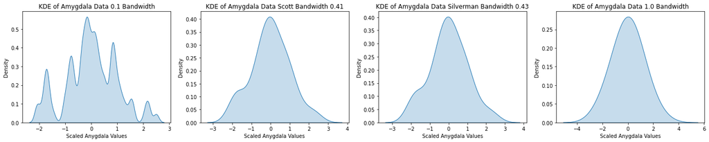

```python
fig,axs = plt.subplots(nrows=1,ncols=4,figsize=(24,4))
sns.kdeplot(sklearn.preprocessing.scale(amygdala),bw=0.1,shade=True,ax=axs[0])
axs[0].set_title('KDE of Amygdala Data 0.1 Bandwidth')
axs[0].set_xlabel('Scaled Anygdala Values')
axs[0].set_ylabel('Density')
sns.kdeplot(sklearn.preprocessing.scale(amygdala),bw='scott',shade=True,ax=axs[1])
axs[1].set_title('KDE of Amygdala Data Scott Bandwidth 0.41')
axs[1].set_xlabel('Scaled Anygdala Values')
axs[1].set_ylabel('Density')
sns.kdeplot(sklearn.preprocessing.scale(amygdala),bw='silverman',shade=True,ax=axs[2])
axs[2].set_title('KDE of Amygdala Data Silverman Bandwidth 0.43')
axs[2].set_xlabel('Scaled Anygdala Values')
axs[2].set_ylabel('Density')
sns.kdeplot(sklearn.preprocessing.scale(amygdala),bw=1.0,shade=True,ax=axs[3])
axs[3].set_title('KDE of Amygdala Data 1.0 Bandwidth')
axs[3].set_xlabel('Scaled Anygdala Values')
axs[3].set_ylabel('Density')
plt.show()
```

### Anterior Cingulate Cortex Gaussian Kernel Density Estimator:

As we demonstrated above with its application to the amygdala feature, we can also use KDE to better understand our Acc feature. The results are shown below beginning with again an interactive chart based on the user chosen parameterization of the functions bandwidth and followed by various static representation of the chart at interesting values of bandwidth for comparison's sake.

```python
def acc_kde_single(bandwidth):
    sns.kdeplot(sklearn.preprocessing.scale(acc),bw=bandwidth,shade=True)
    plt.title('Acc Gaussian KDE with Bandwidth = %s'%bandwidth)
    plt.ylabel('Density')
    plt.xlabel('Scaled Acc Values')
widgets.interact(acc_kde_single, bandwidth=widgets.FloatSlider(min=.001,max=1.0,step=0.01,value =round(scipy.stats.gaussian_kde(sklearn.preprocessing.scale(acc),bw_method='scott').factor,2)))
plt.show()
```

### Static Acc Gaussian Kernel Density Estimator Plots with Varying Bandwidth:

We will perform a similar static bandwidth value analysis as demonstrated above on Amygdala this time for the Acc feature. The results is plotted below:

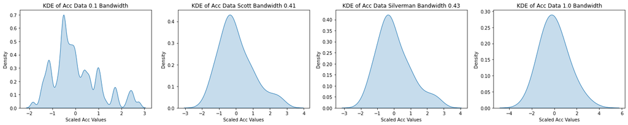

```python
fig,axs = plt.subplots(nrows=1,ncols=4,figsize=(24,4))
sns.kdeplot(sklearn.preprocessing.scale(acc),bw=0.1,shade=True,ax=axs[0])
axs[0].set_title('KDE of Acc Data 0.1 Bandwidth')
axs[0].set_xlabel('Scaled Acc Values')
axs[0].set_ylabel('Density')
sns.kdeplot(sklearn.preprocessing.scale(acc),bw='scott',shade=True,ax=axs[1])
axs[1].set_title('KDE of Acc Data Scott Bandwidth 0.41')
axs[1].set_xlabel('Scaled Acc Values')
axs[1].set_ylabel('Density')
sns.kdeplot(sklearn.preprocessing.scale(acc),bw='silverman',shade=True,ax=axs[2])
axs[2].set_title('KDE of Acc Data Silverman Bandwidth 0.43')
axs[2].set_xlabel('Scaled Acc Values')
axs[2].set_ylabel('Density')
sns.kdeplot(sklearn.preprocessing.scale(acc),bw=1.0,shade=True,ax=axs[3])
axs[3].set_title('KDE of Acc Data 1.0 Bandwidth')
axs[3].set_xlabel('Scaled Acc Values')
axs[3].set_ylabel('Density')
plt.show()
```

As we can see from the plots above we observe much of the same behavior as we saw in the KDE plots of the Amygdala data. Our small bandwidth values result in very discontinuous distribution visualizations. On the other hand, as we approach a bandwidth value of one our graph becomes excessively normalized allowing little insight into the structure of our dataset. For these reasons we again will go with the Silverman bandwidth as the optimal bandwidth parameterization of the Acc KDE. The Silverman and Scott values are too close to differentiate here so we will defer to industry standard judgement and continue with Silverman bandwidth.

The chart below demonstrates the 3D plot of the 2-feature histogram relating Amygdala and Acc. The plot is represented with an interactive slider used to determine the number of bins specified to the plot, which the user can adjust as they see fit.

### 3D Histogram Plot for Joint Distribution of Amygdala and Acc:

```python
def histogram_3d(bins):
    fig = plt.figure(figsize=(9,9))
    ax = fig.add_subplot(111, projection='3d')
    x = amygdala
    y = acc
    abs_min = min(np.min(amygdala),np.min(acc))
    abs_max = max(np.max(amygdala),np.max(acc))
    increment = (abs_max - abs_min) / bins
    bound_list = [abs_min,abs_max]
    range_array = np.reshape(np.repeat(np.array(bound_list),2),(2,2)).T
    hist, xedges, yedges = np.histogram2d(x,y, bins=bins,range=[[-0.0676,0.0812], [-0.0676,0.0812]])
    xpos, ypos = np.meshgrid(xedges[:-1] + increment, yedges[:-1]+increment)
    xpos = xpos.ravel()
    ypos = ypos.ravel()
    zpos = 0
    dx = dy = increment * np.ones_like(zpos)
    dz = hist.ravel()
    cmap = cm.get_cmap('coolwarm')
    max_height = np.max(dz)
    min_height = np.min(dz)
    rgba = [cmap((k-min_height)/max_height) for k in dz]
    ax.bar3d(xpos, ypos, zpos, dx, dy, dz,color=rgba,shade=True)
    ax.set_title('3D Histogram for Amygdala and Acc')
    ax.set_zlabel('Frequency')
    ax.set_xlabel('Acc')
    ax.set_ylabel('Amygdala')
    plt.show()
interactive_plot_h = interactive(histogram_3d,bins=widgets.IntSlider(min=3, max=20, step=1, value=10))
output_h = interactive_plot_h.children[-1]
output_h.layout.height = '520px'
interactive_plot_h
```

### Static 3D Histogram Plots for Amygdala vs. ACC with Varying Number of Bins:

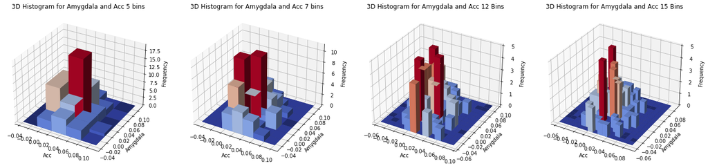

```python
fig= plt.figure(figsize=(24,6))
axs0 = fig.add_subplot(1, 4, 1, projection='3d')

x = amygdala
y = acc
abs_min = min(np.min(amygdala),np.min(acc))
abs_max = max(np.max(amygdala),np.max(acc))
increment = (abs_max - abs_min) / 5
bound_list = [abs_min,abs_max]
range_array = np.reshape(np.repeat(np.array(bound_list),2),(2,2)).T
hist, xedges, yedges = np.histogram2d(x,y, bins=5,range=[[-0.0676,0.0812], [-0.0676,0.0812]])
xpos, ypos = np.meshgrid(xedges[:-1] + increment, yedges[:-1]+increment)
xpos = xpos.ravel()
ypos = ypos.ravel()
zpos = 0
dx = dy = increment * np.ones_like(zpos)
dz = hist.ravel()
cmap = cm.get_cmap('coolwarm')
max_height = np.max(dz)
min_height = np.min(dz)
rgba = [cmap((k-min_height)/max_height) for k in dz]
axs0.bar3d(xpos, ypos, zpos, dx, dy, dz,color=rgba,shade=True)
axs0.set_title('3D Histogram for Amygdala and Acc 5 bins')
axs0.set_zlabel('Frequency')
axs0.set_xlabel('Acc')
axs0.set_ylabel('Amygdala')

axs1 = fig.add_subplot(1, 4, 2, projection='3d')
x = amygdala
y = acc
abs_min = min(np.min(amygdala),np.min(acc))
abs_max = max(np.max(amygdala),np.max(acc))
increment = (abs_max - abs_min) / 7
bound_list = [abs_min,abs_max]
range_array = np.reshape(np.repeat(np.array(bound_list),2),(2,2)).T
hist, xedges, yedges = np.histogram2d(x,y, bins=7,range=[[-0.0676,0.0812], [-0.0676,0.0812]])
xpos, ypos = np.meshgrid(xedges[:-1] + increment, yedges[:-1]+increment)
xpos = xpos.ravel()
ypos = ypos.ravel()
zpos = 0
dx = dy = increment * np.ones_like(zpos)
dz = hist.ravel()
cmap = cm.get_cmap('coolwarm')
max_height = np.max(dz)
min_height = np.min(dz)
rgba = [cmap((k-min_height)/max_height) for k in dz]
axs1.bar3d(xpos, ypos, zpos, dx, dy, dz,color=rgba,shade=True)
axs1.set_title('3D Histogram for Amygdala and Acc 7 bins')
axs1.set_zlabel('Frequency')
axs1.set_xlabel('Acc')
axs1.set_ylabel('Amygdala')

axs2 = fig.add_subplot(1, 4, 3, projection='3d')
x = amygdala
y = acc
abs_min = min(np.min(amygdala),np.min(acc))
abs_max = max(np.max(amygdala),np.max(acc))
increment = (abs_max - abs_min) / 12
bound_list = [abs_min,abs_max]
range_array = np.reshape(np.repeat(np.array(bound_list),2),(2,2)).T
hist, xedges, yedges = np.histogram2d(x,y, bins=12,range=[[-0.0676,0.0812], [-0.0676,0.0812]])
xpos, ypos = np.meshgrid(xedges[:-1] + increment, yedges[:-1]+increment)
xpos = xpos.ravel()
ypos = ypos.ravel()
zpos = 0
dx = dy = increment * np.ones_like(zpos)
dz = hist.ravel()
cmap = cm.get_cmap('coolwarm')
max_height = np.max(dz)
min_height = np.min(dz)
rgba = [cmap((k-min_height)/max_height) for k in dz]
axs2.bar3d(xpos, ypos, zpos, dx, dy, dz,color=rgba,shade=True)
axs2.set_title('3D Histogram for Amygdala and Acc 12 Bins')
axs2.set_zlabel('Frequency')
axs2.set_xlabel('Acc')
axs2.set_ylabel('Amygdala')

axs3 = fig.add_subplot(1, 4, 4, projection='3d')
x = amygdala
y = acc
abs_min = min(np.min(amygdala),np.min(acc))
abs_max = max(np.max(amygdala),np.max(acc))
increment = (abs_max - abs_min) / 15
bound_list = [abs_min,abs_max]
range_array = np.reshape(np.repeat(np.array(bound_list),2),(2,2)).T
hist, xedges, yedges = np.histogram2d(x,y, bins=15,range=[[-0.0676,0.0812], [-0.0676,0.0812]])
xpos, ypos = np.meshgrid(xedges[:-1] + increment, yedges[:-1]+increment)
xpos = xpos.ravel()
ypos = ypos.ravel()
zpos = 0
dx = dy = increment * np.ones_like(zpos)
dz = hist.ravel()
cmap = cm.get_cmap('coolwarm')
max_height = np.max(dz)
min_height = np.min(dz)
rgba = [cmap((k-min_height)/max_height) for k in dz]
axs3.bar3d(xpos, ypos, zpos, dx, dy, dz,color=rgba,shade=True)
axs3.set_title('3D Histogram for Amygdala and Acc 15 Bins')
axs3.set_zlabel('Frequency')
axs3.set_xlabel('Acc')
axs3.set_ylabel('Amygdala')

plt.show()
```

The above 3D plots of varying bin width demonstrate the continued requirement of a good parameterization for histogram bootstrapping a distribution. In the 2D case we were concerned primarily with continuity and the presence of empty bins. However, in the 3D unscaled cases above we see that having our plot as a cube and given the shape of the data requires empty bins in the plot in all cases. The 3D case should be evaluated more on the basis of having few empty bins in the heart of the data cloud and accept empty bins so long as they fall on the cube's fringes. As we can see from the plots above evaluating on these guidelines it is probably quite clear that the latter two cases of bins = 12 and 15 are our best cases for parameterization of the histogram. In the initial two plots we see that our data is too closely structured to gain any real insight. However, in the latter 2 cases, we can clearly see the prevalence of multiple means/modes within the data which suggests our joint distribution of the data we have bootstrapped does not follow properties of independence.

### 3-Dimensional KDE Plot for Amygdala vs. ACC:

Just as we used KDE smooth curves to contrast the rigidity of discrete histograms, we can also apply this same transformation to both feature vector simultaneously in the 3D visualization case for the joint density of Amygdala and Acc features. Just as before, the following graph uses an interactive slider that allows the user to select their desired bandwidth parameter for the KDE calculation. In this implementation, the bandwidth chosen will be the same across features. The bandwidth the plot is initialized with (.50) is the bandwidth I felt demonstrated the qualities of the data properly. However, it is notable that by playing around with various values of bandwidth we see quite interesting behavior from the distribution. Depending on how low we tune the parameter, we can start to see the emergence of three distinct peaks within the surface plot. This would indicate that our data has some not so independent properties.

```python
##Axes might be swaped label wise check that before submission
def surface_plot_kde(bandwidth):
    data = np.copy(dual_array)
    data = sklearn.preprocessing.scale(data)
    abs_min = np.min(np.min(data,axis=0))
    abs_max = np.max(np.max(data,axis=0))
    grid_boxes = 50
    increments = (abs_max - abs_min) / grid_boxes
    grid_x, grid_y = np.meshgrid(np.arange(abs_min-increments*2,abs_max+increments*2,increments),np.arange(abs_min-increments*2,abs_max+increments*2,increments))
    grid_merged = (np.asarray([grid_x.flatten(order='F'),grid_y.flatten(order='F')])).T
    num_coords, cord_dims = grid_merged.shape
    m,n = data.shape
    data_normed = (np.power(data, 2)).sum(axis=1)
    h = bandwidth
    grid_normed = (np.power(grid_merged, 2)).sum(axis=1)
    cross = np.dot(data,grid_merged.T)
    kern_input0 = np.repeat(data_normed, repeats =num_coords).reshape((len(data_normed), num_coords))+np.tile(grid_normed, m).reshape((len(data_normed), num_coords)) - 2*cross
    kern_input = np.divide(kern_input0,(2*(h**2)))
    kern_output = (1/(2*math.pi)) * np.exp(-kern_input)
    mesh_kde = (((sum(kern_output) / ((m*h**n))).T).reshape(grid_x.shape[0],grid_y.shape[1])).T
    fig = plt.figure(figsize=(10,10))
    ax=fig.add_subplot(111, projection='3d')
    ax.set_title('Gaussian Kernel Density Estimator for Amygdala and Acc with Bandwidth = %s'%bandwidth)
    ax.set_zlabel('Density')
    ax.set_xlabel('Acc Normalized')
    ax.set_ylabel('Amygdala Normalized')
    surface = ax.plot_surface(grid_x, grid_y, mesh_kde,cmap=cm.coolwarm)
    fig.colorbar(surface,shrink=0.5)
    plt.show()
interactive_plot = interactive(surface_plot_kde,bandwidth=widgets.FloatSlider(min=0.001, max=1, step=0.001, value=0.50))
output = interactive_plot.children[-1]
output.layout.height = '500px'
interactive_plot
```

As we can see by varying the bandwidth in the above joint distributional KDE plot of the data the importance of a proper parameterization of bandwidth is still of prominent importance in the 3D case as it was in single case. By rotating the chart in this space we can see that although at first glance the plot seems quite single modal the two lower peaks or modes are hidden on the back side of the initial visible surface peak. This indicates further support for our assumptions of multi-modality within the data that is present even after scaling and standardization effects. We can again further analyze our parameterization of bandwidth by using static plots of various bandwidth values as shown below:

### Static 3 Dimensional KDE Plots for Amygdala vs. ACC with Varying Values of Bandwidth:

Visualized below are the four static 3D surface plots of the joint distribution:

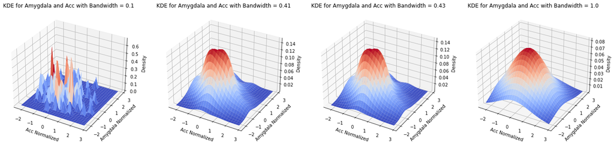

```python
data = np.copy(dual_array)
data = sklearn.preprocessing.scale(data)
abs_min = np.min(np.min(data,axis=0))
abs_max = np.max(np.max(data,axis=0))
grid_boxes = 50
increments = (abs_max - abs_min) / grid_boxes
grid_x, grid_y = np.meshgrid(np.arange(abs_min-increments*2,abs_max+increments*2,increments),np.arange(abs_min-increments*2,abs_max+increments*2,increments))
grid_merged = (np.asarray([grid_x.flatten(order='F'),grid_y.flatten(order='F')])).T
num_coords, cord_dims = grid_merged.shape
m,n = data.shape
data_normed = (np.power(data, 2)).sum(axis=1)
grid_normed = (np.power(grid_merged, 2)).sum(axis=1)
cross = np.dot(data,grid_merged.T)
kern_input0 = np.repeat(data_normed, repeats =num_coords).reshape((len(data_normed), num_coords))+np.tile(grid_normed, m).reshape((len(data_normed), num_coords)) - 2*cross


fig = plt.figure(figsize=(24,8))

ax0 = fig.add_subplot(1, 4, 1, projection='3d')
h = 0.10
kern_input = np.divide(kern_input0,(2*(h**2)))
kern_output = (1/(2*math.pi)) * np.exp(-kern_input)
mesh_kde = (((sum(kern_output) / ((m*h**n))).T).reshape(grid_x.shape[0],grid_y.shape[1])).T
ax0.set_title('KDE for Amygdala and Acc with Bandwidth = %s'%h)
ax0.set_zlabel('Density')
ax0.set_xlabel('Acc Normalized')
ax0.set_ylabel('Amygdala Normalized')
ax0.plot_surface(grid_x, grid_y, mesh_kde,cmap=cm.coolwarm)


ax1=fig.add_subplot(1, 4, 2, projection='3d')
h = 0.41
kern_input = np.divide(kern_input0,(2*(h**2)))
kern_output = (1/(2*math.pi)) * np.exp(-kern_input)
mesh_kde = (((sum(kern_output) / ((m*h**n))).T).reshape(grid_x.shape[0],grid_y.shape[1])).T
ax1.set_title('KDE for Amygdala and Acc with Bandwidth = %s'%h)
ax1.set_zlabel('Density')
ax1.set_xlabel('Acc Normalized')
ax1.set_ylabel('Amygdala Normalized')
ax1.plot_surface(grid_x, grid_y, mesh_kde,cmap=cm.coolwarm)


ax2=fig.add_subplot(1, 4, 3, projection='3d')
h = 0.43
kern_input = np.divide(kern_input0,(2*(h**2)))
kern_output = (1/(2*math.pi)) * np.exp(-kern_input)
mesh_kde = (((sum(kern_output) / ((m*h**n))).T).reshape(grid_x.shape[0],grid_y.shape[1])).T
ax2.set_title('KDE for Amygdala and Acc with Bandwidth = %s'%h)
ax2.set_zlabel('Density')
ax2.set_xlabel('Acc Normalized')
ax2.set_ylabel('Amygdala Normalized')
ax2.plot_surface(grid_x, grid_y, mesh_kde,cmap=cm.coolwarm)

ax3=fig.add_subplot(1, 4, 4, projection='3d')
h = 1.0
kern_input = np.divide(kern_input0,(2*(h**2)))
kern_output = (1/(2*math.pi)) * np.exp(-kern_input)
mesh_kde = (((sum(kern_output) / ((m*h**n))).T).reshape(grid_x.shape[0],grid_y.shape[1])).T
ax3.set_title('KDE for Amygdala and Acc with Bandwidth = %s'%h)
ax3.set_zlabel('Density')
ax3.set_xlabel('Acc Normalized')
ax3.set_ylabel('Amygdala Normalized')
ax3.plot_surface(grid_x, grid_y, mesh_kde,cmap=cm.coolwarm)


plt.show()
```

Similarly, to the previous discussion on bandwidth parameterization it is apparent in the plots of above as well as the interactive plot above that the Silverman method yields our most interoperable parameterization of bandwidth. We can see under both Silverman and Scott's values of bandwidth the subtle valley in the peak of the distributions that indicates multi-modality. These are the same peaks examined in the previous analysis above clearly seen on figure rotation. It is notable that just as we saw in the 2D cases of KDE and Histogram distribution bootstrapping the 3D cases of KDE and Histogram bootstrapping still remain highly similar discrete and continues analogues of one another respectively.

### Joint Probability Density Map of P (Amygdala, Acc):

We can further visualize the joint distribution of Amygdala and Acc features by utilizing 2D contour plots to get even more understanding of the data structure. As in prior graphs the bandwidth is set at the initial optimum and allows interactive output.

```python
joint_data = sklearn.preprocessing.scale(dual_array).T
def marginal_contour(bandwidth):
    countour_grid = np.linspace(start=-3.5,stop=3.5,num=200)
    x_mesh,y_mesh = np.meshgrid(countour_grid,countour_grid)
    pos = np.vstack([x_mesh.ravel(),y_mesh.ravel()])
    joint_data = sklearn.preprocessing.scale(dual_array).T
    marginal_kde_obj = scipy.stats.gaussian_kde(joint_data,bw_method=bandwidth)
    marginal_density = np.reshape(scipy.stats.gaussian_kde.evaluate(marginal_kde_obj,pos),(countour_grid.shape[0],countour_grid.shape[0]))
    plt.contourf(countour_grid,countour_grid,marginal_density,cmap=cm.coolwarm)
    plt.title('Marginal Probablity Density Map of P(Amygdala,Acc)')
    plt.ylabel('Acc Normalized')
    plt.xlabel('Amygdala Normalized')
    plt.colorbar(shrink=.5)
widgets.interact(marginal_contour, bandwidth=widgets.FloatSlider(min=.001,max=1.0,step=0.01,value=scipy.stats.gaussian_kde(joint_data,bw_method='silverman').factor))
plt.show()
```

The plot above essentially gives a flattened bird's eye view of the 3D KDE surface plots shown above. In many ways the contour plot provides much more interesting details despite the compressed representation. We can see clearly the deformed shape of the distribution with its very steep mean in the immediately recognizable dark red. We further analyze the joint distribution below by again using static plots with varying bandwidth for side-by-side comparisons which are shown below:

### Static Marginal Probability Density Map of P(Amygdala ,Acc) with Varying Bandwidth Values:

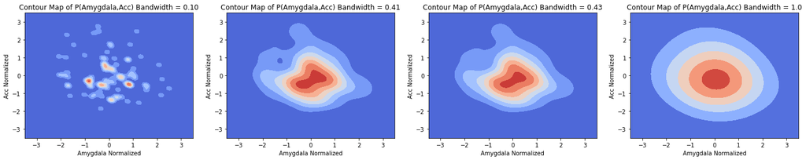

```python
countour_grid = np.linspace(start=-3.5,stop=3.5,num=200)
x_mesh,y_mesh = np.meshgrid(countour_grid,countour_grid)
pos = np.vstack([x_mesh.ravel(),y_mesh.ravel()])
joint_data = sklearn.preprocessing.scale(dual_array).T
fig,axs = plt.subplots(nrows=1,ncols=4,figsize=(24,4))
marginal_kde_obj = scipy.stats.gaussian_kde(joint_data,bw_method=0.1)
marginal_density = np.reshape(scipy.stats.gaussian_kde.evaluate(marginal_kde_obj,pos),(countour_grid.shape[0],countour_grid.shape[0]))


axs[0].contourf(countour_grid,countour_grid,marginal_density,cmap=cm.coolwarm)
axs[0].set_title('Contour Map of P(Amygdala,Acc) Bandwidth = 0.10')
axs[0].set_ylabel('Acc Normalized')
axs[0].set_xlabel('Amygdala Normalized')

marginal_kde_obj = scipy.stats.gaussian_kde(joint_data,bw_method=0.41)
marginal_density = np.reshape(scipy.stats.gaussian_kde.evaluate(marginal_kde_obj,pos),(countour_grid.shape[0],countour_grid.shape[0]))
axs[1].contourf(countour_grid,countour_grid,marginal_density,cmap=cm.coolwarm)
axs[1].set_title('Contour Map of P(Amygdala,Acc) Bandwidth = 0.41')
axs[1].set_ylabel('Acc Normalized')
axs[1].set_xlabel('Amygdala Normalized')


marginal_kde_obj = scipy.stats.gaussian_kde(joint_data,bw_method=0.43)
marginal_density = np.reshape(scipy.stats.gaussian_kde.evaluate(marginal_kde_obj,pos),(countour_grid.shape[0],countour_grid.shape[0]))
axs[2].contourf(countour_grid,countour_grid,marginal_density,cmap=cm.coolwarm)
axs[2].set_title('Contour Map of P(Amygdala,Acc) Bandwidth = 0.43')
axs[2].set_ylabel('Acc Normalized')
axs[2].set_xlabel('Amygdala Normalized')


marginal_kde_obj = scipy.stats.gaussian_kde(joint_data,bw_method=1.0)
marginal_density = np.reshape(scipy.stats.gaussian_kde.evaluate(marginal_kde_obj,pos),(countour_grid.shape[0],countour_grid.shape[0]))
axs[3].contourf(countour_grid,countour_grid,marginal_density,cmap=cm.coolwarm)
axs[3].set_title('Contour Map of P(Amygdala,Acc) Bandwidth = 1.0')
axs[3].set_ylabel('Acc Normalized')
axs[3].set_xlabel('Amygdala Normalized')
plt.show()
```

As we can see from the plots above the Silverman and Scott methods of bandwidth parameterization prove the most useful as far as visualization utility goes. In both of the middle plots it is readily visible that the distribution is mis formed. Of most notable insight is small blue artifact present within the light blue outer level contours within the second plot. This along with the extended tail-like blob emerging at the peak of charts 2 and 3 show some non-normal distributional properties.

### Product of Marginal Probability Densities of P(Amygdala)P(Acc):

We can further visualize the joint distribution of Amygdala and Acc features by utilizing 2D contour plots of the products of the marginal distribution of each feature. Ideally, if the feature is independent the product of the two marginal probabilities should be equal or near equal to the joint distribution plots used above. As in prior graphs the bandwidth is set at the initial optimum and allows interactive output which is shown below and initially set to a Silverman method derived bandwidth.

```python
amy_joint = sklearn.preprocessing.scale(amygdala)
acc_joint = sklearn.preprocessing.scale(acc)
def joint_contour(bandwidth):
    countour_grid = np.linspace(start=-3.5,stop=3.5,num=200)
    amy_joint = sklearn.preprocessing.scale(amygdala)
    acc_joint = sklearn.preprocessing.scale(acc)
    amy_kde_obj = scipy.stats.gaussian_kde(amy_joint,bw_method=bandwidth)
    acc_kde_obj = scipy.stats.gaussian_kde(acc_joint,bw_method=bandwidth)
    amy_kde_density = scipy.stats.gaussian_kde.evaluate(amy_kde_obj,countour_grid)
    acc_kde_density = scipy.stats.gaussian_kde.evaluate(acc_kde_obj,countour_grid)
    joint_density = np.dot(acc_kde_density[:,np.newaxis],amy_kde_density[:,np.newaxis].T)
    plt.contourf(countour_grid,countour_grid,joint_density,cmap=cm.coolwarm)
    plt.title('Joint Probablity Density Map of P(Amygdala)P(Acc)')
    plt.ylabel('Acc Normalized')
    plt.xlabel('Amygdala Normalized')
    plt.colorbar(shrink=.5)
widgets.interact(joint_contour, bandwidth=widgets.FloatSlider(min=.001,max=1.0,step=0.01,value=scipy.stats.gaussian_kde(amy_joint,bw_method='silverman').factor))
plt.show()
```

The graph above differs from our expectation of similarity to the previous joint plots in a few keyways. There appears to be a pull of the outer contour levels towards the upper y axis and the leftmost x direction. It appears that these effects are readily visible in the upper plots, but their behavior seems to somewhat disrupted in the upper chart as evidence by the island like artifact in the upper plots. Unlike the product distribution the joint distribution displays far more unusual non-normal behavior and shape than would be expected as seen above. We can again further analyze the distribution via additional static plots with varying bandwidth as shown below:

### Static Joint Probability Density Map of P(Amygdala)(Acc) with Varying Bandwidth Values:

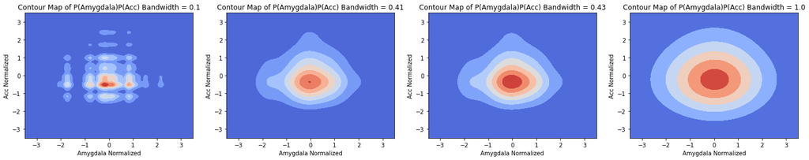

```python
amy_joint = sklearn.preprocessing.scale(amygdala)
acc_joint = sklearn.preprocessing.scale(acc)
countour_grid = np.linspace(start=-3.5,stop=3.5,num=200)

fig,axs = plt.subplots(nrows=1,ncols=4,figsize=(24,4))
amy_kde_obj = scipy.stats.gaussian_kde(amy_joint,bw_method=0.10)
acc_kde_obj = scipy.stats.gaussian_kde(acc_joint,bw_method=0.10)
amy_kde_density = scipy.stats.gaussian_kde.evaluate(amy_kde_obj,countour_grid)
acc_kde_density = scipy.stats.gaussian_kde.evaluate(acc_kde_obj,countour_grid)
joint_density = np.dot(acc_kde_density[:,np.newaxis],amy_kde_density[:,np.newaxis].T)
axs[0].contourf(countour_grid,countour_grid,joint_density,cmap=cm.coolwarm)
axs[0].set_title('Contour Map of P(Amygdala)P(Acc) Bandwidth = 0.1')
axs[0].set_ylabel('Acc Normalized')
axs[0].set_xlabel('Amygdala Normalized')


amy_kde_obj = scipy.stats.gaussian_kde(amy_joint,bw_method=0.41)
acc_kde_obj = scipy.stats.gaussian_kde(acc_joint,bw_method=0.41)
amy_kde_density = scipy.stats.gaussian_kde.evaluate(amy_kde_obj,countour_grid)
acc_kde_density = scipy.stats.gaussian_kde.evaluate(acc_kde_obj,countour_grid)
joint_density = np.dot(acc_kde_density[:,np.newaxis],amy_kde_density[:,np.newaxis].T)
axs[1].contourf(countour_grid,countour_grid,joint_density,cmap=cm.coolwarm)
axs[1].set_title('Contour Map of P(Amygdala)P(Acc) Bandwidth = 0.41')
axs[1].set_ylabel('Acc Normalized')
axs[1].set_xlabel('Amygdala Normalized')


amy_kde_obj = scipy.stats.gaussian_kde(amy_joint,bw_method=0.43)
acc_kde_obj = scipy.stats.gaussian_kde(acc_joint,bw_method=0.43)
amy_kde_density = scipy.stats.gaussian_kde.evaluate(amy_kde_obj,countour_grid)
acc_kde_density = scipy.stats.gaussian_kde.evaluate(acc_kde_obj,countour_grid)
joint_density = np.dot(acc_kde_density[:,np.newaxis],amy_kde_density[:,np.newaxis].T)
axs[2].contourf(countour_grid,countour_grid,joint_density,cmap=cm.coolwarm)
axs[2].set_title('Contour Map of P(Amygdala)P(Acc) Bandwidth = 0.43')
axs[2].set_ylabel('Acc Normalized')
axs[2].set_xlabel('Amygdala Normalized')


amy_kde_obj = scipy.stats.gaussian_kde(amy_joint,bw_method=1.0)
acc_kde_obj = scipy.stats.gaussian_kde(acc_joint,bw_method=1.0)
amy_kde_density = scipy.stats.gaussian_kde.evaluate(amy_kde_obj,countour_grid)
acc_kde_density = scipy.stats.gaussian_kde.evaluate(acc_kde_obj,countour_grid)
joint_density = np.dot(acc_kde_density[:,np.newaxis],amy_kde_density[:,np.newaxis].T)
axs[3].contourf(countour_grid,countour_grid,joint_density,cmap=cm.coolwarm)
axs[3].set_title('Contour Map of P(Amygdala)P(Acc) Bandwidth = 1.0')
axs[3].set_ylabel('Acc Normalized')
axs[3].set_xlabel('Amygdala Normalized')
plt.show()
```

As we have explored in depth in prior analysis the Silverman usually proves to be our optimal visualization of the product of the marginal densities of these two features however, in this case we find Scott's method ideal. In this iteration of plots, it is apparent that the Scott's method differs quite a bit which hasn't been an observation of difference between the two until this point. We can see that Scott's method place a very small almost pinpoint mean whereas Silverman's has a far more recognizable and encompassing mean. This could indicate a sensitive large valued mean observation that is hidden in higher bandwidths thus Scotts method is chosen as optimal because it preserves this behavior for little cost as demonstrated by the similarity of contour shapes between the iterations. As we examined above the product of these marginal distributions differs in many key areas from the joint distributional plot indicating non-normality and or lack of independence in the joint distribution. In order to further explore these hypothesis we can form error plots that map the differences in the two contour plots. These methods are explored below:

### Probability Density Error Map of Amygdala and Acc:

Now here is where the real insight can be obtained, we can now compare the absolute difference between the conditional and joint distributions obtained above in order to assess their independence. If the distributions are in-fact independent then, we should see minimal strong disturbances in the error plot.

```python
amy_joint = sklearn.preprocessing.scale(amygdala)
acc_joint = sklearn.preprocessing.scale(acc)
joint_data = sklearn.preprocessing.scale(dual_array).T

def error_plot_reg(bandwidth):
    countour_grid = np.linspace(start=-3.5,stop=3.5,num=200)
    x_mesh,y_mesh = np.meshgrid(countour_grid,countour_grid)
    pos = np.vstack([x_mesh.ravel(),y_mesh.ravel()])
    joint_data = sklearn.preprocessing.scale(dual_array).T
    marginal_kde_obj = scipy.stats.gaussian_kde(joint_data,bw_method=bandwidth)
    marginal_density = np.reshape(scipy.stats.gaussian_kde.evaluate(marginal_kde_obj,pos),(countour_grid.shape[0],countour_grid.shape[0]))
    countour_grid = np.linspace(start=-3.5,stop=3.5,num=200)
    amy_joint = sklearn.preprocessing.scale(amygdala)
    acc_joint = sklearn.preprocessing.scale(acc)
    amy_kde_obj = scipy.stats.gaussian_kde(amy_joint,bw_method=bandwidth)
    acc_kde_obj = scipy.stats.gaussian_kde(acc_joint,bw_method=bandwidth)
    amy_kde_density = scipy.stats.gaussian_kde.evaluate(amy_kde_obj,countour_grid)
    acc_kde_density = scipy.stats.gaussian_kde.evaluate(acc_kde_obj,countour_grid)
    joint_density = np.dot(acc_kde_density[:,np.newaxis],amy_kde_density[:,np.newaxis].T)
    error_density = np.absolute(marginal_density - joint_density)
    plt.contourf(countour_grid,countour_grid,error_density,cmap=cm.coolwarm)
    plt.title('Error Density Map of P(Amygdala,Acc) vs. P(Amygdala)P(Acc)')
    plt.ylabel('Acc Normalized')
    plt.xlabel('Amygdala Normalized')
    plt.colorbar(shrink=.5)
widgets.interact(error_plot_reg, bandwidth=widgets.FloatSlider(min=.001,max=1.0,step=0.01,value=scipy.stats.gaussian_kde(amy_joint,bw_method='silverman').factor))
plt.show()
```

As we can clearly see from the above error plot, even at varying levels of bandwidth it is difficult not find that the plots have at times primarily 3 areas of heat which indicate multi-modal distributions that are not very independent of one another nor jointly normal. Again we further expresses these views in static plots below of varying bandwidth:

### Static Probability Density Error Maps of Amygdala and Acc with Varying Bandwidth Values:

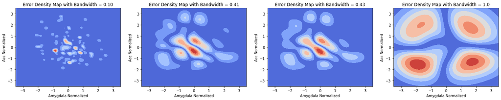

```python
amy_joint = sklearn.preprocessing.scale(amygdala)
acc_joint = sklearn.preprocessing.scale(acc)
joint_data = sklearn.preprocessing.scale(dual_array).T
countour_grid = np.linspace(start=-3.5,stop=3.5,num=200)
x_mesh,y_mesh = np.meshgrid(countour_grid,countour_grid)
pos = np.vstack([x_mesh.ravel(),y_mesh.ravel()])
joint_data = sklearn.preprocessing.scale(dual_array).T

fig,axs = plt.subplots(nrows=1,ncols=4,figsize=(24,4))

marginal_kde_obj = scipy.stats.gaussian_kde(joint_data,bw_method=0.10)
marginal_density = np.reshape(scipy.stats.gaussian_kde.evaluate(marginal_kde_obj,pos),(countour_grid.shape[0],countour_grid.shape[0]))
countour_grid = np.linspace(start=-3.5,stop=3.5,num=200)
amy_joint = sklearn.preprocessing.scale(amygdala)
acc_joint = sklearn.preprocessing.scale(acc)
amy_kde_obj = scipy.stats.gaussian_kde(amy_joint,bw_method=0.10)
acc_kde_obj = scipy.stats.gaussian_kde(acc_joint,bw_method=0.10)
amy_kde_density = scipy.stats.gaussian_kde.evaluate(amy_kde_obj,countour_grid)
acc_kde_density = scipy.stats.gaussian_kde.evaluate(acc_kde_obj,countour_grid)
joint_density = np.dot(acc_kde_density[:,np.newaxis],amy_kde_density[:,np.newaxis].T)
error_density = np.absolute(marginal_density - joint_density)
axs[0].contourf(countour_grid,countour_grid,error_density,cmap=cm.coolwarm)
axs[0].set_title('Error Density Map with Bandwidth = 0.10')
axs[0].set_ylabel('Acc Normalized')
axs[0].set_xlabel('Amygdala Normalized')


marginal_kde_obj = scipy.stats.gaussian_kde(joint_data,bw_method=0.41)
marginal_density = np.reshape(scipy.stats.gaussian_kde.evaluate(marginal_kde_obj,pos),(countour_grid.shape[0],countour_grid.shape[0]))
countour_grid = np.linspace(start=-3.5,stop=3.5,num=200)
amy_joint = sklearn.preprocessing.scale(amygdala)
acc_joint = sklearn.preprocessing.scale(acc)
amy_kde_obj = scipy.stats.gaussian_kde(amy_joint,bw_method=0.41)
acc_kde_obj = scipy.stats.gaussian_kde(acc_joint,bw_method=0.41)
amy_kde_density = scipy.stats.gaussian_kde.evaluate(amy_kde_obj,countour_grid)
acc_kde_density = scipy.stats.gaussian_kde.evaluate(acc_kde_obj,countour_grid)
joint_density = np.dot(acc_kde_density[:,np.newaxis],amy_kde_density[:,np.newaxis].T)
error_density = np.absolute(marginal_density - joint_density)
axs[1].contourf(countour_grid,countour_grid,error_density,cmap=cm.coolwarm)
axs[1].set_title('Error Density Map with Bandwidth = 0.41')
axs[1].set_ylabel('Acc Normalized')
axs[1].set_xlabel('Amygdala Normalized')


marginal_kde_obj = scipy.stats.gaussian_kde(joint_data,bw_method=0.43)
marginal_density = np.reshape(scipy.stats.gaussian_kde.evaluate(marginal_kde_obj,pos),(countour_grid.shape[0],countour_grid.shape[0]))
countour_grid = np.linspace(start=-3.5,stop=3.5,num=200)
amy_joint = sklearn.preprocessing.scale(amygdala)
acc_joint = sklearn.preprocessing.scale(acc)
amy_kde_obj = scipy.stats.gaussian_kde(amy_joint,bw_method=0.43)
acc_kde_obj = scipy.stats.gaussian_kde(acc_joint,bw_method=0.43)
amy_kde_density = scipy.stats.gaussian_kde.evaluate(amy_kde_obj,countour_grid)
acc_kde_density = scipy.stats.gaussian_kde.evaluate(acc_kde_obj,countour_grid)
joint_density = np.dot(acc_kde_density[:,np.newaxis],amy_kde_density[:,np.newaxis].T)
error_density = np.absolute(marginal_density - joint_density)
axs[2].contourf(countour_grid,countour_grid,error_density,cmap=cm.coolwarm)
axs[2].set_title('Error Density Map with Bandwidth = 0.43')
axs[2].set_ylabel('Acc Normalized')
axs[2].set_xlabel('Amygdala Normalized')


marginal_kde_obj = scipy.stats.gaussian_kde(joint_data,bw_method=1.0)
marginal_density = np.reshape(scipy.stats.gaussian_kde.evaluate(marginal_kde_obj,pos),(countour_grid.shape[0],countour_grid.shape[0]))
countour_grid = np.linspace(start=-3.5,stop=3.5,num=200)
amy_joint = sklearn.preprocessing.scale(amygdala)
acc_joint = sklearn.preprocessing.scale(acc)
amy_kde_obj = scipy.stats.gaussian_kde(amy_joint,bw_method=1.0)
acc_kde_obj = scipy.stats.gaussian_kde(acc_joint,bw_method=1.0)
amy_kde_density = scipy.stats.gaussian_kde.evaluate(amy_kde_obj,countour_grid)
acc_kde_density = scipy.stats.gaussian_kde.evaluate(acc_kde_obj,countour_grid)
joint_density = np.dot(acc_kde_density[:,np.newaxis],amy_kde_density[:,np.newaxis].T)
error_density = np.absolute(marginal_density - joint_density)
axs[3].contourf(countour_grid,countour_grid,error_density,cmap=cm.coolwarm)
axs[3].set_title('Error Density Map with Bandwidth = 1.0')
axs[3].set_ylabel('Acc Normalized')
axs[3].set_xlabel('Amygdala Normalized')

plt.show()
```

As demonstrated by our interactive error plot above our data is quite non-normal and not independent under any view of distinct bandwidth parameterization. These plots again reinforce the idea that our joint distribution is multimodal and far different from the would-be independent distribution of the product of the two marginal probabilities. Additionally, the error plots demonstrate that the differences are very difficult to reconcile given the amorphous shapes of the contours especially those near the central mean.

### Amygdala Condtioned on various values of Orientation and bandwidth:

Furthering our analysis from above, we can add even more detail to the analysis of each feature by conditioning their KDE's on our target variable Orientation which takes values 2-5 within our dataset. As before we use sliders below to demonstrate the multiple combinations of conditioning orientations and various bandwiths. Each of these bandwidth is set at the silverman method reccomended value.

```python
def amygdala_kde_conditioned(bandwidth,Orient):
    amygdala_conditioned = amygdala[np.where(orientation == Orient)[0]]
    sns.kdeplot(sklearn.preprocessing.scale(amygdala_conditioned),bw=bandwidth,shade=True)
    plt.title('Amygdala Gaussian KDE Conditioned on Orientation = %s'%Orient)
    plt.ylabel('Density')
    plt.xlabel('Scaled Anygdala Values')
widgets.interact(amygdala_kde_conditioned, bandwidth=widgets.FloatSlider(min=.01,max=1.0,step=0.01, value=round(scipy.stats.gaussian_kde(sklearn.preprocessing.scale(amygdala),bw_method='silverman').factor,2)),Orient=widgets.IntSlider(min=2,max=5,step=1))
plt.show()
```

Each of the static conditioned plots are shown below in order to better compare the conditioned distribution of amygdala for varying values of orientation. Each is parameterized with a Silverman method bandwidth.

### Static Charts of Amygdala Condtioned on various values of Orientation with Silverman Bandwidth:

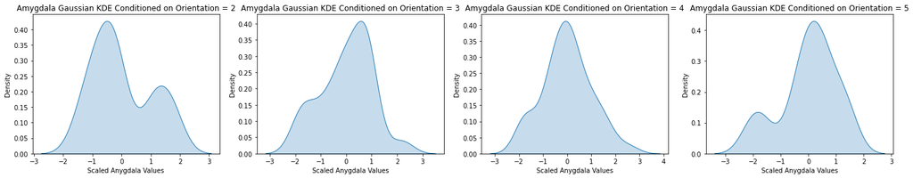

```python
fig,axs = plt.subplots(nrows=1,ncols=4,figsize=(24,4))
bandwidth=0.43
Orient =2
amygdala_conditioned = amygdala[np.where(orientation == Orient)[0]]
sns.kdeplot(sklearn.preprocessing.scale(amygdala_conditioned),bw=bandwidth,shade=True,ax=axs[0])
axs[0].set_title('Amygdala Gaussian KDE Conditioned on Orientation = %s'%Orient)
axs[0].set_ylabel('Density')
axs[0].set_xlabel('Scaled Anygdala Values')

Orient =3
amygdala_conditioned = amygdala[np.where(orientation == Orient)[0]]
sns.kdeplot(sklearn.preprocessing.scale(amygdala_conditioned),bw=bandwidth,shade=True,ax=axs[1])
axs[1].set_title('Amygdala Gaussian KDE Conditioned on Orientation = %s'%Orient)
axs[1].set_ylabel('Density')
axs[1].set_xlabel('Scaled Anygdala Values')


Orient =4
amygdala_conditioned = amygdala[np.where(orientation == Orient)[0]]
sns.kdeplot(sklearn.preprocessing.scale(amygdala_conditioned),bw=bandwidth,shade=True,ax=axs[2])
axs[2].set_title('Amygdala Gaussian KDE Conditioned on Orientation = %s'%Orient)
axs[2].set_ylabel('Density')
axs[2].set_xlabel('Scaled Anygdala Values')


Orient =5
amygdala_conditioned = amygdala[np.where(orientation == Orient)[0]]
sns.kdeplot(sklearn.preprocessing.scale(amygdala_conditioned),bw=bandwidth,shade=True,ax=axs[3])
axs[3].set_title('Amygdala Gaussian KDE Conditioned on Orientation = %s'%Orient)
axs[3].set_ylabel('Density')
axs[3].set_xlabel('Scaled Anygdala Values')

plt.show()
```

Given the above plots, it is interesting to observe that the tails of the distributions for the more extreme pollical orientations are far heavier for amygdala volume when compared to the individuals who identify as more moderate in orientation. Given the amygdala's well known association with the primitive human emotion of fear it seems that there could be an interesting relationship between these observations, but just looking at this data alone is by no means sufficient enough to even consider such a conclusion. Next we can apply this type of analysis to the Acc feature as discussed below:

### Acc Condtioned on various values of Orientation and bandwidth:

Just as we demonstrated on the condition of the amygdala feature, we can conduct a similar analysis with the acc feature. We first use the below interactive chart to provide a means for the user to undependably observe and parameterize the data for quick exploration and data analysis. This chart is shown below:

```python
def acc_kde_conditioned(bandwidth,Orient):
    acc_conditioned = acc[np.where(orientation == Orient)[0]]
    sns.kdeplot(sklearn.preprocessing.scale(acc_conditioned),bw=bandwidth,shade=True)
    plt.title('Acc Gaussian KDE Conditioned on Orientation = %s'%Orient)
    plt.ylabel('Density')
    plt.xlabel('Scaled Acc Values')
widgets.interact(acc_kde_conditioned, bandwidth=widgets.FloatSlider(min=.001,max=1.0,step=0.01,value =round(scipy.stats.gaussian_kde(sklearn.preprocessing.scale(acc),bw_method='silverman').factor,2)),Orient=widgets.IntSlider(min=2,max=5,step=1))
plt.show()
```

We can again further analyze this condition with static plots of each conditioned distribution. These plots are shown below and are all parameterized on the Silverman optimal bandwidth:

### Static Charts of Acc Condtioned on various values of Orientation with Silverman Bandwidth:

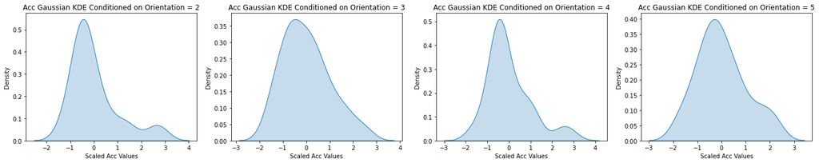

```python
fig,axs = plt.subplots(nrows=1,ncols=4,figsize=(24,4))
bandwidth=0.43
Orient =2
acc_conditioned = acc[np.where(orientation == Orient)[0]]
sns.kdeplot(sklearn.preprocessing.scale(acc_conditioned),bw=bandwidth,shade=True,ax=axs[0])
axs[0].set_title('Acc Gaussian KDE Conditioned on Orientation = %s'%Orient)
axs[0].set_ylabel('Density')
axs[0].set_xlabel('Scaled Acc Values')

Orient =3
acc_conditioned = acc[np.where(orientation == Orient)[0]]
sns.kdeplot(sklearn.preprocessing.scale(acc_conditioned),bw=bandwidth,shade=True,ax=axs[1])
axs[1].set_title('Acc Gaussian KDE Conditioned on Orientation = %s'%Orient)
axs[1].set_ylabel('Density')
axs[1].set_xlabel('Scaled Acc Values')


Orient =4
acc_conditioned = acc[np.where(orientation == Orient)[0]]
sns.kdeplot(sklearn.preprocessing.scale(acc_conditioned),bw=bandwidth,shade=True,ax=axs[2])
axs[2].set_title('Acc Gaussian KDE Conditioned on Orientation = %s'%Orient)
axs[2].set_ylabel('Density')
axs[2].set_xlabel('Scaled Acc Values')


Orient =5
acc_conditioned = acc[np.where(orientation == Orient)[0]]
sns.kdeplot(sklearn.preprocessing.scale(acc_conditioned),bw=bandwidth,shade=True,ax=axs[3])
axs[3].set_title('Acc Gaussian KDE Conditioned on Orientation = %s'%Orient)
axs[3].set_ylabel('Density')
axs[3].set_xlabel('Scaled Acc Values')

plt.show()
```

The above plots demonstrate that the behavior observed in the amygdala doesn't carry directly through in observing the conditioning of Acc. It is readily notable that orientations 2 and 4 yield a vastly similar distribution. Separating these two plots is the most moderate orientation of 3 which mirrors a slightly skewed normal quite well. Finally, we see that in the most liberal orientation a thicker right side which is interesting noting the notable absence of a heavy right side in orientation 2 and 4, but also notable in both these cases is the presence of a heavy right-side tail not as extreme in 3 or 5 Orientations respectively. Again, common knowledge suggests that the Acc portion of the brain is responsible for feelings of empathy in humans. This is also very interesting considering it very much follows surface level expectations. However, again this assertion is completely subjective and makes a lot of dangerous assumptions such as the connection between the volume of a brain area relating to higher functioning of that related brain function. As a data analyst not a doctor such observations are merely observations and offer no definitive conclusions.

### Contour plot of the conditioned joint distribution of Amygdala and Acc conditioning on various values of Orientation and Bandwidth:

We again take a similar approach of contour plotting the 2D joint case and product of marginal case of the KDE estimators of both variables. However, this time we offer an additional view of the data by conditioning each on their respective values of orientation. Below we provide and interactive chart which allows the user to quickly visualize these various conditioning value results along with the impact of bandwidth on the plots of the conditioned joint distribution:

```python
def conditioned_marginal_contour(bandwidth,C):
    countour_grid = np.linspace(start=-3.5,stop=3.5,num=200)
    x_mesh,y_mesh = np.meshgrid(countour_grid,countour_grid)
    pos = np.vstack([x_mesh.ravel(),y_mesh.ravel()])
    conditioned_array = dual_array[np.where(orientation == C)[0],:]
    marginal_data_conditioned = sklearn.preprocessing.scale(conditioned_array).T
    marginal_kde_obj = scipy.stats.gaussian_kde(marginal_data_conditioned,bw_method=bandwidth)
    marginal_density = np.reshape(scipy.stats.gaussian_kde.evaluate(marginal_kde_obj,pos),(countour_grid.shape[0],countour_grid.shape[0]))
    plt.contourf(countour_grid,countour_grid,marginal_density,cmap=cm.coolwarm)
    plt.title('Marginal Density Map Conditioned on Orientation = %s'%C)
    plt.ylabel('Acc Normalized')
    plt.xlabel('Amygdala Normalized')
    plt.colorbar(shrink=.5)
widgets.interact(conditioned_marginal_contour, bandwidth=widgets.FloatSlider(min=.001,max=1.0,step=0.01,value =round(scipy.stats.gaussian_kde(sklearn.preprocessing.scale(acc),bw_method='silverman').factor,2)),C=widgets.IntSlider(min=2,max=5,step=1))
plt.show()
```

Again, we can use static plots to better visualize the effect of conditioning. Each of these conditions is plotted individually below each with the same Silverman parameterization of bandwidth.

### Static Contour plot of the conditional joint distribution of Amygdala and Acc conditioning on various values of Orientation with Silverman Bandwidth:

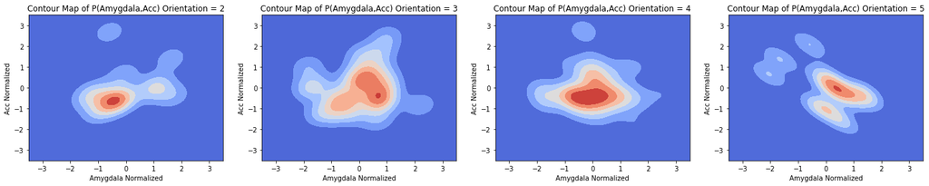

```python
countour_grid = np.linspace(start=-3.5,stop=3.5,num=200)
x_mesh,y_mesh = np.meshgrid(countour_grid,countour_grid)
pos = np.vstack([x_mesh.ravel(),y_mesh.ravel()])
joint_data = sklearn.preprocessing.scale(dual_array).T
fig,axs = plt.subplots(nrows=1,ncols=4,figsize=(24,4))
bandwidth = 0.43

C=2
conditioned_array = dual_array[np.where(orientation == C)[0],:]
marginal_data_conditioned = sklearn.preprocessing.scale(conditioned_array).T
marginal_kde_obj = scipy.stats.gaussian_kde(marginal_data_conditioned,bw_method=bandwidth)
marginal_density = np.reshape(scipy.stats.gaussian_kde.evaluate(marginal_kde_obj,pos),(countour_grid.shape[0],countour_grid.shape[0]))
axs[0].contourf(countour_grid,countour_grid,marginal_density,cmap=cm.coolwarm)
axs[0].set_title('Contour Map of P(Amygdala,Acc) Orientation = 2')
axs[0].set_ylabel('Acc Normalized')
axs[0].set_xlabel('Amygdala Normalized')

C=3
conditioned_array = dual_array[np.where(orientation == C)[0],:]
marginal_data_conditioned = sklearn.preprocessing.scale(conditioned_array).T
marginal_kde_obj = scipy.stats.gaussian_kde(marginal_data_conditioned,bw_method=bandwidth)
marginal_density = np.reshape(scipy.stats.gaussian_kde.evaluate(marginal_kde_obj,pos),(countour_grid.shape[0],countour_grid.shape[0]))
axs[1].contourf(countour_grid,countour_grid,marginal_density,cmap=cm.coolwarm)
axs[1].set_title('Contour Map of P(Amygdala,Acc) Orientation = 3')
axs[1].set_ylabel('Acc Normalized')
axs[1].set_xlabel('Amygdala Normalized')

C=4
conditioned_array = dual_array[np.where(orientation == C)[0],:]
marginal_data_conditioned = sklearn.preprocessing.scale(conditioned_array).T
marginal_kde_obj = scipy.stats.gaussian_kde(marginal_data_conditioned,bw_method=bandwidth)
marginal_density = np.reshape(scipy.stats.gaussian_kde.evaluate(marginal_kde_obj,pos),(countour_grid.shape[0],countour_grid.shape[0]))
axs[2].contourf(countour_grid,countour_grid,marginal_density,cmap=cm.coolwarm)
axs[2].set_title('Contour Map of P(Amygdala,Acc) Orientation = 4')
axs[2].set_ylabel('Acc Normalized')
axs[2].set_xlabel('Amygdala Normalized')

C=5
conditioned_array = dual_array[np.where(orientation == C)[0],:]
marginal_data_conditioned = sklearn.preprocessing.scale(conditioned_array).T
marginal_kde_obj = scipy.stats.gaussian_kde(marginal_data_conditioned,bw_method=bandwidth)
marginal_density = np.reshape(scipy.stats.gaussian_kde.evaluate(marginal_kde_obj,pos),(countour_grid.shape[0],countour_grid.shape[0]))
axs[3].contourf(countour_grid,countour_grid,marginal_density,cmap=cm.coolwarm)
axs[3].set_title('Contour Map of P(Amygdala,Acc) Orientation = 5')
axs[3].set_ylabel('Acc Normalized')
axs[3].set_xlabel('Amygdala Normalized')
plt.show()
```

Although the joint plots are generally amorphous, they lend themselves to some interesting insights in the middle and outer cases respectively. The outer plots which represent the two most extreme ends of our orientations have the most deformed and multimodal structure. Looking at the middle two plots of the more moderate pollical afflictions we see somewhat more normality. In the case of the third plot we see that condition on orientation 4 yields an island like outlier separate from the distribution which can also be similarly visualized in the first plot. This may indicate some similar structure that needs to be investigated further.

### Product of Marginal Probablites of P(Amygdala)P(Acc) Conditioned on Orientation:

As we applied in the analysis above we carry out a similar procedure of plotting the conditioned forms of the contoured product of these two marginal distributions. Below we first include an interactive user plot to use for quick data exploration and testing.

```python
def joint_contour_conditioned(bandwidth,Orient):
    countour_grid = np.linspace(start=-3.5,stop=3.5,num=200)
    amygdala_conditioned = amygdala[np.where(orientation==Orient)[0]]
    acc_conditioned = acc[np.where(orientation==Orient)[0]]
    amy_joint = sklearn.preprocessing.scale(amygdala_conditioned)
    acc_joint = sklearn.preprocessing.scale(acc_conditioned)
    amy_kde_obj = scipy.stats.gaussian_kde(amy_joint,bw_method=bandwidth)
    acc_kde_obj = scipy.stats.gaussian_kde(acc_joint,bw_method=bandwidth)
    amy_kde_density = scipy.stats.gaussian_kde.evaluate(amy_kde_obj,countour_grid)
    acc_kde_density = scipy.stats.gaussian_kde.evaluate(acc_kde_obj,countour_grid)
    joint_density = np.dot(acc_kde_density[:,np.newaxis],amy_kde_density[:,np.newaxis].T)
    plt.contourf(countour_grid,countour_grid,joint_density,cmap=cm.coolwarm)
    plt.title('Joint Probablity Density Map Conditioned on Orientation = %s'%Orient)
    plt.ylabel('Acc Normalized')
    plt.xlabel('Amygdala Normalized')
    plt.colorbar(shrink=.5)
widgets.interact(joint_contour_conditioned, bandwidth=widgets.FloatSlider(min=.001,max=1.0,step=0.01,value=scipy.stats.gaussian_kde(amy_joint,bw_method='silverman').factor),Orient=widgets.IntSlider(min=2,max=5,step=1))
plt.show()
```

Again, we can further analyze these plots in static form to better observe differences in the conditioning of the distributions and their respective effects. Like before we use Silverman's method of bandwidth parameterization on each of the following plots:

### Static Contour Plots of the Joint Probablity of P(Amygdala)P(Acc) Conditioned on Various Orientations with Silverman Bandwidth:

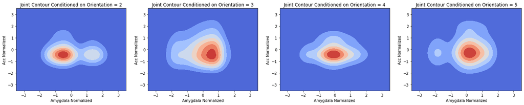

```python
fig,axs = plt.subplots(nrows=1,ncols=4,figsize=(24,4))
bandwidth = 0.43
countour_grid = np.linspace(start=-3.5,stop=3.5,num=200)

Orient = 2
amygdala_conditioned = amygdala[np.where(orientation==Orient)[0]]
acc_conditioned = acc[np.where(orientation==Orient)[0]]
amy_joint = sklearn.preprocessing.scale(amygdala_conditioned)
acc_joint = sklearn.preprocessing.scale(acc_conditioned)
amy_kde_obj = scipy.stats.gaussian_kde(amy_joint,bw_method=bandwidth)
acc_kde_obj = scipy.stats.gaussian_kde(acc_joint,bw_method=bandwidth)
amy_kde_density = scipy.stats.gaussian_kde.evaluate(amy_kde_obj,countour_grid)
acc_kde_density = scipy.stats.gaussian_kde.evaluate(acc_kde_obj,countour_grid)
joint_density = np.dot(acc_kde_density[:,np.newaxis],amy_kde_density[:,np.newaxis].T)
axs[0].contourf(countour_grid,countour_grid,joint_density,cmap=cm.coolwarm)
axs[0].set_title('Joint Contour Conditioned on Orientation = %s'%Orient)
axs[0].set_ylabel('Acc Normalized')
axs[0].set_xlabel('Amygdala Normalized')

Orient = 3
amygdala_conditioned = amygdala[np.where(orientation==Orient)[0]]
acc_conditioned = acc[np.where(orientation==Orient)[0]]
amy_joint = sklearn.preprocessing.scale(amygdala_conditioned)
acc_joint = sklearn.preprocessing.scale(acc_conditioned)
amy_kde_obj = scipy.stats.gaussian_kde(amy_joint,bw_method=bandwidth)
acc_kde_obj = scipy.stats.gaussian_kde(acc_joint,bw_method=bandwidth)
amy_kde_density = scipy.stats.gaussian_kde.evaluate(amy_kde_obj,countour_grid)
acc_kde_density = scipy.stats.gaussian_kde.evaluate(acc_kde_obj,countour_grid)
joint_density = np.dot(acc_kde_density[:,np.newaxis],amy_kde_density[:,np.newaxis].T)
axs[1].contourf(countour_grid,countour_grid,joint_density,cmap=cm.coolwarm)
axs[1].set_title('Joint Contour Conditioned on Orientation = %s'%Orient)
axs[1].set_ylabel('Acc Normalized')
axs[1].set_xlabel('Amygdala Normalized')

Orient = 4
amygdala_conditioned = amygdala[np.where(orientation==Orient)[0]]
acc_conditioned = acc[np.where(orientation==Orient)[0]]
amy_joint = sklearn.preprocessing.scale(amygdala_conditioned)
acc_joint = sklearn.preprocessing.scale(acc_conditioned)
amy_kde_obj = scipy.stats.gaussian_kde(amy_joint,bw_method=bandwidth)
acc_kde_obj = scipy.stats.gaussian_kde(acc_joint,bw_method=bandwidth)
amy_kde_density = scipy.stats.gaussian_kde.evaluate(amy_kde_obj,countour_grid)
acc_kde_density = scipy.stats.gaussian_kde.evaluate(acc_kde_obj,countour_grid)
joint_density = np.dot(acc_kde_density[:,np.newaxis],amy_kde_density[:,np.newaxis].T)
axs[2].contourf(countour_grid,countour_grid,joint_density,cmap=cm.coolwarm)
axs[2].set_title('Joint Contour Conditioned on Orientation = %s'%Orient)
axs[2].set_ylabel('Acc Normalized')
axs[2].set_xlabel('Amygdala Normalized')

Orient = 5
amygdala_conditioned = amygdala[np.where(orientation==Orient)[0]]
acc_conditioned = acc[np.where(orientation==Orient)[0]]
amy_joint = sklearn.preprocessing.scale(amygdala_conditioned)
acc_joint = sklearn.preprocessing.scale(acc_conditioned)
amy_kde_obj = scipy.stats.gaussian_kde(amy_joint,bw_method=bandwidth)
acc_kde_obj = scipy.stats.gaussian_kde(acc_joint,bw_method=bandwidth)
amy_kde_density = scipy.stats.gaussian_kde.evaluate(amy_kde_obj,countour_grid)
acc_kde_density = scipy.stats.gaussian_kde.evaluate(acc_kde_obj,countour_grid)
joint_density = np.dot(acc_kde_density[:,np.newaxis],amy_kde_density[:,np.newaxis].T)
axs[3].contourf(countour_grid,countour_grid,joint_density,cmap=cm.coolwarm)
axs[3].set_title('Joint Contour Conditioned on Orientation = %s'%Orient)
axs[3].set_ylabel('Acc Normalized')
axs[3].set_xlabel('Amygdala Normalized')

plt.show()
```

The above plots indicate some interesting relations as we can see by moving right form the first plot there is a contour that extends form the central data cloud right ward. This behavior continues until reaching the third plot or the containing on orientation 4 where we observe the most normal looking of the plots. Finally, as we move to the right most plot we observe this same appendage to the contour central plot this time extending to the left. The convergence of the direction of these appendages around the middle plots could indicate some interesting data behavior in the underlying distribution.

### Error Map of P(Amygdala,Acc) vs. P(Amygdala)P(Acc) Conditioned on Orientation:

We again extend our analysis of the conditioned distributions to a conditioned error plot. As before we first display an interactive error plot for the user to quickly explore the data and its relationships to bandwidth and orientation conditioning.

```python
def error_plot_conditioned(bandwidth,Orient):
    countour_grid = np.linspace(start=-3.5,stop=3.5,num=200)
    x_mesh,y_mesh = np.meshgrid(countour_grid,countour_grid)
    pos = np.vstack([x_mesh.ravel(),y_mesh.ravel()])
    joint_data = dual_array[np.where(orientation == Orient)[0],:]
    joint_data = sklearn.preprocessing.scale(joint_data).T
    marginal_kde_obj = scipy.stats.gaussian_kde(joint_data,bw_method=bandwidth)
    marginal_density = np.reshape(scipy.stats.gaussian_kde.evaluate(marginal_kde_obj,pos),(countour_grid.shape[0],countour_grid.shape[0]))
    countour_grid = np.linspace(start=-3.5,stop=3.5,num=200)
    amy_joint = amygdala[np.where(orientation==Orient)[0]]
    acc_joint = acc[np.where(orientation==Orient)[0]]
    amy_joint = sklearn.preprocessing.scale(amy_joint)
    acc_joint = sklearn.preprocessing.scale(acc_joint)
    amy_kde_obj = scipy.stats.gaussian_kde(amy_joint,bw_method=bandwidth)
    acc_kde_obj = scipy.stats.gaussian_kde(acc_joint,bw_method=bandwidth)
    amy_kde_density = scipy.stats.gaussian_kde.evaluate(amy_kde_obj,countour_grid)
    acc_kde_density = scipy.stats.gaussian_kde.evaluate(acc_kde_obj,countour_grid)
    joint_density = np.dot(acc_kde_density[:,np.newaxis],amy_kde_density[:,np.newaxis].T)
    error_density = np.absolute(marginal_density - joint_density)
    plt.contourf(countour_grid,countour_grid,error_density,cmap=cm.coolwarm)
    plt.title('Error Density Map Conditioned on Orientation = %s'%Orient)
    plt.ylabel('Acc Normalized')
    plt.xlabel('Amygdala Normalized')
    plt.colorbar(shrink=.5)
widgets.interact(error_plot_conditioned, bandwidth=widgets.FloatSlider(min=.001,max=1.0,step=0.01,value=scipy.stats.gaussian_kde(joint_data,bw_method='silverman').factor),Orient=widgets.IntSlider(min=2,max=5,step=1))
plt.show()
```

Again, we extend this analysis to static plots for further side-by-side comparison. Each is parameterized upon Silverman’s bandwidth method:

### Static Error Maps of P(Amygdala,Acc) vs. P(Amygdala)P(Acc) Conditioned on Various Orientations with Silverman Bandwidth:

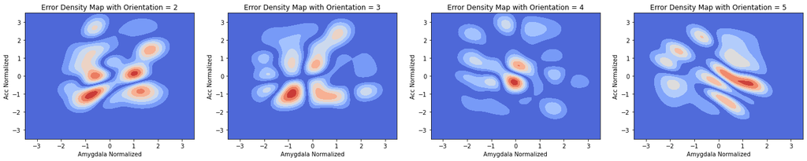

```python
countour_grid = np.linspace(start=-3.5,stop=3.5,num=200)
x_mesh,y_mesh = np.meshgrid(countour_grid,countour_grid)
pos = np.vstack([x_mesh.ravel(),y_mesh.ravel()])

bandwidth = 0.43
fig,axs = plt.subplots(nrows=1,ncols=4,figsize=(24,4))

Orient = 2
countour_grid = np.linspace(start=-3.5,stop=3.5,num=200)
x_mesh,y_mesh = np.meshgrid(countour_grid,countour_grid)
pos = np.vstack([x_mesh.ravel(),y_mesh.ravel()])
joint_data = dual_array[np.where(orientation == Orient)[0],:]
joint_data = sklearn.preprocessing.scale(joint_data).T
marginal_kde_obj = scipy.stats.gaussian_kde(joint_data,bw_method=bandwidth)
marginal_density = np.reshape(scipy.stats.gaussian_kde.evaluate(marginal_kde_obj,pos),(countour_grid.shape[0],countour_grid.shape[0]))
countour_grid = np.linspace(start=-3.5,stop=3.5,num=200)
amy_joint = amygdala[np.where(orientation==Orient)[0]]
acc_joint = acc[np.where(orientation==Orient)[0]]
amy_joint = sklearn.preprocessing.scale(amy_joint)
acc_joint = sklearn.preprocessing.scale(acc_joint)
amy_kde_obj = scipy.stats.gaussian_kde(amy_joint,bw_method=bandwidth)
acc_kde_obj = scipy.stats.gaussian_kde(acc_joint,bw_method=bandwidth)
amy_kde_density = scipy.stats.gaussian_kde.evaluate(amy_kde_obj,countour_grid)
acc_kde_density = scipy.stats.gaussian_kde.evaluate(acc_kde_obj,countour_grid)
joint_density = np.dot(acc_kde_density[:,np.newaxis],amy_kde_density[:,np.newaxis].T)
error_density = np.absolute(marginal_density - joint_density)
axs[0].contourf(countour_grid,countour_grid,error_density,cmap=cm.coolwarm)
axs[0].set_title('Error Density Map with Orientation = %s'%Orient)
axs[0].set_ylabel('Acc Normalized')
axs[0].set_xlabel('Amygdala Normalized')


Orient = 3
countour_grid = np.linspace(start=-3.5,stop=3.5,num=200)
x_mesh,y_mesh = np.meshgrid(countour_grid,countour_grid)
pos = np.vstack([x_mesh.ravel(),y_mesh.ravel()])
joint_data = dual_array[np.where(orientation == Orient)[0],:]
joint_data = sklearn.preprocessing.scale(joint_data).T
marginal_kde_obj = scipy.stats.gaussian_kde(joint_data,bw_method=bandwidth)
marginal_density = np.reshape(scipy.stats.gaussian_kde.evaluate(marginal_kde_obj,pos),(countour_grid.shape[0],countour_grid.shape[0]))
countour_grid = np.linspace(start=-3.5,stop=3.5,num=200)
amy_joint = amygdala[np.where(orientation==Orient)[0]]
acc_joint = acc[np.where(orientation==Orient)[0]]
amy_joint = sklearn.preprocessing.scale(amy_joint)
acc_joint = sklearn.preprocessing.scale(acc_joint)
amy_kde_obj = scipy.stats.gaussian_kde(amy_joint,bw_method=bandwidth)
acc_kde_obj = scipy.stats.gaussian_kde(acc_joint,bw_method=bandwidth)
amy_kde_density = scipy.stats.gaussian_kde.evaluate(amy_kde_obj,countour_grid)
acc_kde_density = scipy.stats.gaussian_kde.evaluate(acc_kde_obj,countour_grid)
joint_density = np.dot(acc_kde_density[:,np.newaxis],amy_kde_density[:,np.newaxis].T)
error_density = np.absolute(marginal_density - joint_density)
axs[1].contourf(countour_grid,countour_grid,error_density,cmap=cm.coolwarm)
axs[1].set_title('Error Density Map with Orientation = %s'%Orient)
axs[1].set_ylabel('Acc Normalized')
axs[1].set_xlabel('Amygdala Normalized')

Orient = 4
countour_grid = np.linspace(start=-3.5,stop=3.5,num=200)
x_mesh,y_mesh = np.meshgrid(countour_grid,countour_grid)
pos = np.vstack([x_mesh.ravel(),y_mesh.ravel()])
joint_data = dual_array[np.where(orientation == Orient)[0],:]
joint_data = sklearn.preprocessing.scale(joint_data).T
marginal_kde_obj = scipy.stats.gaussian_kde(joint_data,bw_method=bandwidth)
marginal_density = np.reshape(scipy.stats.gaussian_kde.evaluate(marginal_kde_obj,pos),(countour_grid.shape[0],countour_grid.shape[0]))
countour_grid = np.linspace(start=-3.5,stop=3.5,num=200)
amy_joint = amygdala[np.where(orientation==Orient)[0]]
acc_joint = acc[np.where(orientation==Orient)[0]]
amy_joint = sklearn.preprocessing.scale(amy_joint)
acc_joint = sklearn.preprocessing.scale(acc_joint)
amy_kde_obj = scipy.stats.gaussian_kde(amy_joint,bw_method=bandwidth)
acc_kde_obj = scipy.stats.gaussian_kde(acc_joint,bw_method=bandwidth)
amy_kde_density = scipy.stats.gaussian_kde.evaluate(amy_kde_obj,countour_grid)
acc_kde_density = scipy.stats.gaussian_kde.evaluate(acc_kde_obj,countour_grid)
joint_density = np.dot(acc_kde_density[:,np.newaxis],amy_kde_density[:,np.newaxis].T)
error_density = np.absolute(marginal_density - joint_density)
axs[2].contourf(countour_grid,countour_grid,error_density,cmap=cm.coolwarm)
axs[2].set_title('Error Density Map with Orientation = %s'%Orient)
axs[2].set_ylabel('Acc Normalized')
axs[2].set_xlabel('Amygdala Normalized')

Orient = 5
countour_grid = np.linspace(start=-3.5,stop=3.5,num=200)
x_mesh,y_mesh = np.meshgrid(countour_grid,countour_grid)
pos = np.vstack([x_mesh.ravel(),y_mesh.ravel()])
joint_data = dual_array[np.where(orientation == Orient)[0],:]
joint_data = sklearn.preprocessing.scale(joint_data).T
marginal_kde_obj = scipy.stats.gaussian_kde(joint_data,bw_method=bandwidth)
marginal_density = np.reshape(scipy.stats.gaussian_kde.evaluate(marginal_kde_obj,pos),(countour_grid.shape[0],countour_grid.shape[0]))
countour_grid = np.linspace(start=-3.5,stop=3.5,num=200)
amy_joint = amygdala[np.where(orientation==Orient)[0]]
acc_joint = acc[np.where(orientation==Orient)[0]]
amy_joint = sklearn.preprocessing.scale(amy_joint)
acc_joint = sklearn.preprocessing.scale(acc_joint)
amy_kde_obj = scipy.stats.gaussian_kde(amy_joint,bw_method=bandwidth)
acc_kde_obj = scipy.stats.gaussian_kde(acc_joint,bw_method=bandwidth)
amy_kde_density = scipy.stats.gaussian_kde.evaluate(amy_kde_obj,countour_grid)
acc_kde_density = scipy.stats.gaussian_kde.evaluate(acc_kde_obj,countour_grid)
joint_density = np.dot(acc_kde_density[:,np.newaxis],amy_kde_density[:,np.newaxis].T)
error_density = np.absolute(marginal_density - joint_density)
axs[3].contourf(countour_grid,countour_grid,error_density,cmap=cm.coolwarm)
axs[3].set_title('Error Density Map with Orientation = %s'%Orient)
axs[3].set_ylabel('Acc Normalized')
axs[3].set_xlabel('Amygdala Normalized')

plt.show()
```

The error plots above unsurprisingly each display a lack of data normality independence and unimodality regardless of bandwidth or conditioning impacts. However, it is notable that the error plots range widely in difference with each different conditioning of orientation. We see that in the first two plots the data distributional differences between the joint distribution and the product of the marginals is confined largely to 4 high density quadrants. The orientation of 4 seems to give us the least differences in distributions but still clear demonstrates two areas of high-density difference. The final plot demonstrates some interesting structure, but it is immediately non-insightful in its current form without further context aside from the differences largely being confined to the lower right on the x axis. Collectively, each of these plots leads to some insightful analysis and insight of the data. However, that comes with a lot of subjective analyst judgements concerning graph interpretation as well as parametrization which do not necessarily have explicit grounding or interpretation. For these reasons parametric or hybrid parametric methods such as these should be approached with extreme caution and diligence. These are a group of estimators that show the "art" like nature of data analysis and also demonstrate the difficulty to strike a balance in local bias vs. global variance with both bandwidth and bin width demonstrate proxies of.